# 데이터 과학 – 금융(Finance)

시계열 데이터 자료구조 - `tsibble`

xwMOOC

Tidyverse Korea

2019-02-23

# 1 시계열 데이터 역학관계

R에서 시계열 데이터를 처리하기 위한 전용 자료구조로 [`zoo`, Z’s Ordered Observations](https://cran.r-project.org/web/packages/zoo/)와 [`xts`, eXtensible Time Series](https://github.com/joshuaulrich/xts)가 많이 활용되었지만, `tidyverse` 등장이후 시계열 자료구조도 [`lubridate`](https://cran.r-project.org/web/packages/lubridate/) 팩키지의 등장 이후 시계열이 아닌 많이 사용되는 데이터프레임에서 표준으로 자리를 잡아가고 있으며 [`tsibble`](https://cran.r-project.org/web/packages/tsibble/)이 두가지 큰 흐름의 간극을 매워가면서 새로운 지평을 열어가고 있다.

[figure not shown]

# 2 `tsibble` 기본 [^1]

tsibble(`tbl_ts`)은 티블(tibble) `tidyverse`의 시계열 자료구조를 확장한 것으로 제작되었고. `ts`, `zoo`, `xts`와 비교하여 볼 때 시간 인덱스를 본질적인 데이터 칼럼으로 둠으로써 이질적인 자료구조 처리를 내재적으로 가능하게 제작되었고 변수 하나 혹은 그 이상으로 구성된 “Key” 개념을 도입해서 시간 흐름에 따라 관측점 단위별로 식별이 가능하게 만들었다.

## 2.1 `tsibble` 객체 생성

`tsibble()` 함수로 `tsibble` 객체를 생성시킬 수 있을 뿐만 아니라 `as_tsibble()` 함수는 S3 메쏘드로 다른 객체를 `tsibble` 객체로 강제변환(coerce)시킨다. `ts`, `mts` 객체는 `as_tsibble()`함수로 `tsibble` 객체를 별도 다른 설정없이 강제변환이 가능한 반면, 티블 혹은 데이터프레임의 경우 인덱스(index)와 키(key) 변수를 식별하기 위해서 추가 작업이 다소 필요하다.

```r
library(tidyverse)
library(tsibble)
library(lubridate)

weather <- nycflights13::weather %>%
  select(origin, time_hour, temp, humid, precip)
weather
```

```
# A tibble: 26,115 x 5
   origin time_hour            temp humid precip
   <chr>  <dttm>              <dbl> <dbl>  <dbl>
 1 EWR    2013-01-01 01:00:00  39.0  59.4      0
 2 EWR    2013-01-01 02:00:00  39.0  61.6      0
 3 EWR    2013-01-01 03:00:00  39.0  64.4      0
 4 EWR    2013-01-01 04:00:00  39.9  62.2      0
 5 EWR    2013-01-01 05:00:00  39.0  64.4      0
 6 EWR    2013-01-01 06:00:00  37.9  67.2      0
 7 EWR    2013-01-01 07:00:00  39.0  64.4      0
 8 EWR    2013-01-01 08:00:00  39.9  62.2      0
 9 EWR    2013-01-01 09:00:00  39.9  62.2      0
10 EWR    2013-01-01 10:00:00  41    59.6      0
# ... with 26,105 more rows
```

`nycflights13::weather` 자료형은 티블로 시간변수는 `time_hour`가 되고, 3개 변수 `temp`, `humid`, `precip`은 관측변수가 되고, `origin`은 관측지점이 된다. `tsibble` 자료형을 설명하기 적합한 요소를 두루갖추고 있다. 티블/데이터프레임을 `tsibble` 객체로 변환시킬 경우 `index=` 인자로 시계열 정보를 담고 있는 변수를 지정하고 `key=` 인자를 통해 관측단위 변수를 지정시킨다. 이를 통해서 관측점(행)을 관측단위별 시계열 자료구조로 준비가 완료되었다. `tsibble` 객체가 생성되면서 내부적으로 키가 있는 경우 키를 기준값으로 정렬이 일차적으로 일어나고 인덱스를 기준으로 다시 한번 정렬된다. 키가 없는 경우 인덱스를 기준으로 정렬된다.

```r
weather_tsbl <- as_tsibble(weather, index=time_hour, key=id(origin))
weather_tsbl
```

```
# A tsibble: 26,115 x 5 [1h] <America/New_York>
# Key:       origin [3]
   origin time_hour            temp humid precip
   <chr>  <dttm>              <dbl> <dbl>  <dbl>
 1 EWR    2013-01-01 01:00:00  39.0  59.4      0
 2 EWR    2013-01-01 02:00:00  39.0  61.6      0
 3 EWR    2013-01-01 03:00:00  39.0  64.4      0
 4 EWR    2013-01-01 04:00:00  39.9  62.2      0
 5 EWR    2013-01-01 05:00:00  39.0  64.4      0
 6 EWR    2013-01-01 06:00:00  37.9  67.2      0
 7 EWR    2013-01-01 07:00:00  39.0  64.4      0
 8 EWR    2013-01-01 08:00:00  39.9  62.2      0
 9 EWR    2013-01-01 09:00:00  39.9  62.2      0
10 EWR    2013-01-01 10:00:00  41    59.6      0
# ... with 26,105 more rows
```

`tsibble` 객체는 자동으로 시계열 기간에 대한 정보를 인식하여 반영시킨다.

- integer/numeric: 단위(unit) 혹은 연도(Y)
- yearquarter/yearqtr: 분기(Q)
- yearmonth/yearmon: 월(M)
- yearweek: 주(W)
- Date: 일(D)
- POSIXct: 시간(h), 분(m), 초(s), 천분의 1초(us), 백만분의 1초(ms)

`Date` 혹은 `POSITct`는 월단위를 지원하지 않지만 `tsibble`은 `yearmonth`/`yearmth`를 지원한다. `weather_tsbl` 객체는 시계열 단위 `[1h]`와 함께 키도 `origin [3]`으로 명시적으로 나타내고 있다.

# 3 `tsibble` 객체 데이터 조작

```r
weather_tsbl %>%
  group_by(origin) %>%
  index_by(month = yearmonth(time_hour)) %>%
  summarise(
    temp_high = max(temp, na.rm = TRUE),
    temp_average = mean(temp, na.rm = TRUE),
    temp_low = min(temp, na.rm = TRUE)
  ) %>%
  DT::datatable()
```

|  | origin | month | temp_high | temp_average | temp_low |
| --- | --- | --- | --- | --- | --- |
| 1 | EWR | 2013-01-01 | 64.4 | 35.5621563342318 | 10.94 |
| 2 | EWR | 2013-02-01 | 55.94 | 34.2633183856502 | 15.98 |
| 3 | EWR | 2013-03-01 | 60.08 | 40.1186541049798 | 26.06 |
| 4 | EWR | 2013-04-01 | 84.02 | 52.9775 | 30.92 |
| 5 | EWR | 2013-05-01 | 93.02 | 63.3202419354839 | 42.98 |
| 6 | EWR | 2013-06-01 | 93.92 | 73.26725 | 55.04 |
| 7 | EWR | 2013-07-01 | 100.04 | 80.702995951417 | 64.04 |
| 8 | EWR | 2013-08-01 | 89.96 | 74.5374830852503 | 59 |
| 9 | EWR | 2013-09-01 | 95 | 67.3047844228095 | 48.02 |
| 10 | EWR | 2013-10-01 | 89.06 | 59.7782065217391 | 33.08 |

[output cut: 26 more lines]

# 4 불규칙 시계열 데이터

데이터프레임을 `tsibble` 객체로 변환시킬 경우 기본디폴트 설정으로 `regular=TRUE`로 되어있다. 하지만, `nycflights13::flights` 데이터프레임의 경우 `carrier`, `flight`를 키로 두고 `as_tsibble()` 함수를 적용시킬 경우 불규칙 시간 간격을 갖는 시계열 데이터가 생성된다.

먼저 `lubridate` 팩키지 `make_datetime()` 함수를 가지고 시계열 날짜시간 `sched_dep_datetime` 변수를 생성시킨다.

```r
flights <- nycflights13::flights %>%
  mutate(sched_dep_datetime = make_datetime(year, month, day, hour, minute, tz = "America/New_York")) %>%
  select(carrier, flight, year, month, day, hour, minute, sched_dep_datetime, dep_delay)
flights
```

```
# A tibble: 336,776 x 9
   carrier flight  year month   day  hour minute sched_dep_datetime
   <chr>    <int> <int> <int> <int> <dbl>  <dbl> <dttm>
 1 UA        1545  2013     1     1     5     15 2013-01-01 05:15:00
 2 UA        1714  2013     1     1     5     29 2013-01-01 05:29:00
 3 AA        1141  2013     1     1     5     40 2013-01-01 05:40:00
 4 B6         725  2013     1     1     5     45 2013-01-01 05:45:00
 5 DL         461  2013     1     1     6      0 2013-01-01 06:00:00
 6 UA        1696  2013     1     1     5     58 2013-01-01 05:58:00
 7 B6         507  2013     1     1     6      0 2013-01-01 06:00:00
 8 EV        5708  2013     1     1     6      0 2013-01-01 06:00:00
 9 B6          79  2013     1     1     6      0 2013-01-01 06:00:00
10 AA         301  2013     1     1     6      0 2013-01-01 06:00:00
# ... with 336,766 more rows, and 1 more variable: dep_delay <dbl>
```

`carrier`, `flight` 변수를 `key=`을 설정하여 관측단위로 지정하고 `make_datetime()` 함수로 생성시킨 `sched_dep_datetime` 변수를 `index=`에 지정하고 `regular = FALSE`으로 불규칙 시계열 자료임을 명시적으로 선엉하여 `tsibble` 객체를 만든다.

```r
flights_tsbl <- as_tsibble(flights, key=id(carrier, flight),
                                    index=sched_dep_datetime,
                                    regular = FALSE)
flights_tsbl
```

```
# A tsibble: 336,776 x 9 [!] <America/New_York>
# Key:       carrier, flight [5,725]
   carrier flight  year month   day  hour minute sched_dep_datetime
   <chr>    <int> <int> <int> <int> <dbl>  <dbl> <dttm>
 1 9E        2900  2013    11     3    15     40 2013-11-03 15:40:00
 2 9E        2900  2013    11     4    15     40 2013-11-04 15:40:00
 3 9E        2900  2013    11     5    15     40 2013-11-05 15:40:00
 4 9E        2900  2013    11     6    15     40 2013-11-06 15:40:00
 5 9E        2900  2013    11     7    15     40 2013-11-07 15:40:00
 6 9E        2900  2013    11     8    15     40 2013-11-08 15:40:00
 7 9E        2900  2013    11     9    15     40 2013-11-09 15:40:00
 8 9E        2900  2013    11    10    15     40 2013-11-10 15:40:00
 9 9E        2900  2013    11    11    15     40 2013-11-11 15:40:00
10 9E        2900  2013    11    12    15     40 2013-11-12 15:40:00
# ... with 336,766 more rows, and 1 more variable: dep_delay <dbl>
```

`flights_tsbl` 객체는 `A tsibble: 336,776 x 9 [!] <America/New_York>`에서 나타나듯이 `[!]` 표식을 통해 불규칙 시계열데이터임을 확인할 수 있다. 불규칙 시계열 데이터를 균등간격을 갖는 시계열 데이터로 변환시킬 경우 `index_by()` + `summarize()`를 사용한다. `A tsibble: 22,789 x 4 [1M]`에 나타난 것처럼 월별 `[1M]`로 균등간격을 갖는 시계열로 변환이 되었다.

```r
flights_tsbl %>%
  group_by(carrier, flight) %>%
  index_by(month = yearmonth(sched_dep_datetime)) %>%
  summarise(delay_mean = mean(dep_delay, na.rm=TRUE)) %>%
  arrange(desc(delay_mean))
```

```
# A tsibble: 22,789 x 4 [1M]
# Key:       carrier, flight [5,725]
# Groups:    carrier [16]
   carrier flight   month delay_mean
   <chr>    <int>   <mth>      <dbl>
 1 UA         372  2013 7       483
 2 UA         488  2013 1       379
 3 DL        1091 2013 12       378.
 4 EV        5017  2013 9       372
 5 9E        3552  2013 3       354
 6 EV        5537  2013 7       350
 7 WN         521  2013 9       346
 8 DL         390  2013 9       334
 9 EV        4670  2013 6       322
10 EV        3261 2013 12       321
# ... with 22,779 more rows
```

# 5 결측값(`NA`) 처리 [^2]

본격적인 시계열 데이터 분석을 위해서 결측값(`NA`)에 대한 면밀한 조사가 선행되어야 한다. 이를 위해서 `tsibble` 팩키지는 다음 함수를 제공하고 있다.

- `has_gaps()`
- `scan_gaps()`
- `count_gaps()`
- `fill_gaps()`

`pedestrian` 데이터셋은 `tsibble` 팩키지에 내장된 `tsibble` 객체로 IoT 센서데이터를 담고 있는데 결측값이 상당수 포함되어 있다. `Sensor` 변수가 관측점별 키 역할을 하고 있으며 총 4개 센서가 있다. `has_gaps()` 함수를 통해 센서 4개 모두 결측값이 존재됨이 확인되었다.

```r
pedestrian
```

```
# A tsibble: 66,037 x 5 [1h] <Australia/Melbourne>
# Key:       Sensor [4]
   Sensor         Date_Time           Date        Time Count
   <chr>          <dttm>              <date>     <int> <int>
 1 Birrarung Marr 2015-01-01 00:00:00 2015-01-01     0  1630
 2 Birrarung Marr 2015-01-01 01:00:00 2015-01-01     1   826
 3 Birrarung Marr 2015-01-01 02:00:00 2015-01-01     2   567
 4 Birrarung Marr 2015-01-01 03:00:00 2015-01-01     3   264
 5 Birrarung Marr 2015-01-01 04:00:00 2015-01-01     4   139
 6 Birrarung Marr 2015-01-01 05:00:00 2015-01-01     5    77
 7 Birrarung Marr 2015-01-01 06:00:00 2015-01-01     6    44
 8 Birrarung Marr 2015-01-01 07:00:00 2015-01-01     7    56
 9 Birrarung Marr 2015-01-01 08:00:00 2015-01-01     8   113
10 Birrarung Marr 2015-01-01 09:00:00 2015-01-01     9   166
# ... with 66,027 more rows
```

```r
has_gaps(pedestrian)
```

```
# A tibble: 4 x 2
  Sensor                        .gaps
  <chr>                         <lgl>
1 Birrarung Marr                TRUE
2 Bourke Street Mall (North)    TRUE
3 QV Market-Elizabeth St (West) TRUE
4 Southern Cross Station        TRUE
```

결측값이 확인되면 다음으로 관심있는 사항은 결측값이 각 센서별로 몇개나 있는지 계산해야 한다. `count_gaps()` 함수를 통해서 각센서별 기간별 결측값이 발생된 횟수를 파악할 수 있다.

```r
pedestrian %>%
  count_gaps(.fill=TRUE) %>%
  arrange(desc(.n))
```

```
# A tibble: 18 x 4
   Sensor                     .from               .to                    .n
   <chr>                      <dttm>              <dttm>              <int>
 1 Birrarung Marr             2016-10-29 00:00:00 2016-11-28 23:00:00   744
 2 Birrarung Marr             2015-10-06 00:00:00 2015-10-31 23:00:00   624
 3 Birrarung Marr             2016-04-08 00:00:00 2016-05-03 23:00:00   624
 4 Birrarung Marr             2015-05-07 00:00:00 2015-05-31 23:00:00   600
 5 Birrarung Marr             2015-11-26 00:00:00 2015-12-04 23:00:00   216
 6 Birrarung Marr             2015-11-20 00:00:00 2015-11-24 23:00:00   120
 7 Birrarung Marr             2015-11-05 00:00:00 2015-11-06 23:00:00    48
 8 QV Market-Elizabeth St (W~ 2015-12-31 00:00:00 2015-12-31 23:00:00    24
 9 Southern Cross Station     2016-03-29 02:00:00 2016-03-29 03:00:00     2
10 Birrarung Marr             2015-04-05 02:00:00 2015-04-05 02:00:00     1
11 Birrarung Marr             2016-04-03 02:00:00 2016-04-03 02:00:00     1
12 Bourke Street Mall (North) 2015-04-05 02:00:00 2015-04-05 02:00:00     1
13 Bourke Street Mall (North) 2016-04-03 02:00:00 2016-04-03 02:00:00     1
14 QV Market-Elizabeth St (W~ 2015-04-05 02:00:00 2015-04-05 02:00:00     1
15 QV Market-Elizabeth St (W~ 2016-04-03 02:00:00 2016-04-03 02:00:00     1
16 Southern Cross Station     2015-04-05 02:00:00 2015-04-05 02:00:00     1
17 Southern Cross Station     2016-03-08 02:00:00 2016-03-08 02:00:00     1
18 Southern Cross Station     2016-04-03 02:00:00 2016-04-03 02:00:00     1
```

다음으로 결측값에 대한 상세한 내용을 파악하려면 `scan_gaps()` 함수를 통해 파악할 수 있다.

```r
pedestrian %>%
  filter(Sensor == "Bourke Street Mall (North)") %>%
  scan_gaps()
```

```
# A tsibble: 2 x 2 [1h] <Australia/Melbourne>
# Key:       Sensor [1]
  Sensor                     Date_Time
  <chr>                      <dttm>
1 Bourke Street Mall (North) 2015-04-05 02:00:00
2 Bourke Street Mall (North) 2016-04-03 02:00:00
```

`ggplot` 팩키지를 통해서 결측값을 시각화하여 파악하는 것도 가능하다. 이를 통해서 센서가 정상적으로 동작하지 않는 기간이 언제였는지 쉽게 파악할 수 있다.

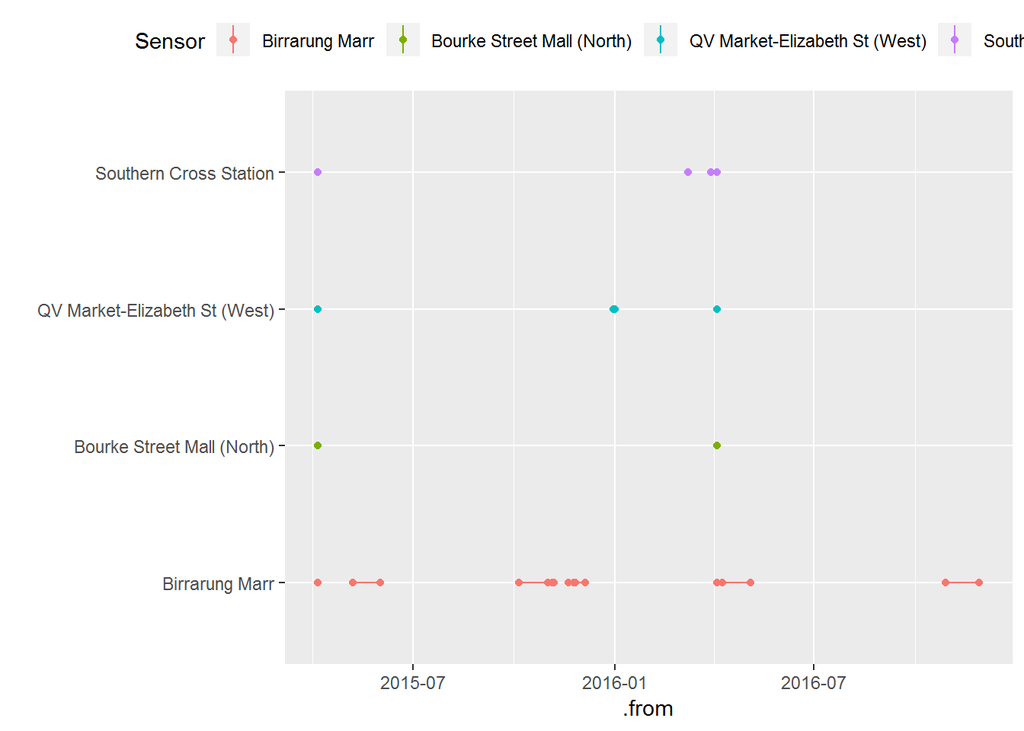

```r
pedestrian %>%
  count_gaps(.fill=TRUE) %>%
  ggplot(aes(x = Sensor, colour = Sensor)) +
    geom_linerange(aes(ymin = .from, ymax = .to)) +
    geom_point(aes(y = .from)) +
    geom_point(aes(y = .to)) +
    coord_flip() +
    theme(legend.position = "top") +
    labs(x="")
```

센서별로 결측값이 발생한 시간을 파악하게 되면 다음 단계로 결측값을 채워넣는다. `fill_gaps()` 함수를 사용한다. 시간별로 빈칸을 `NA`로 채워넣거나 `mean(Count)` 평균값을 포함한 다른 값으로도 채워넣는 것이 가능하다.

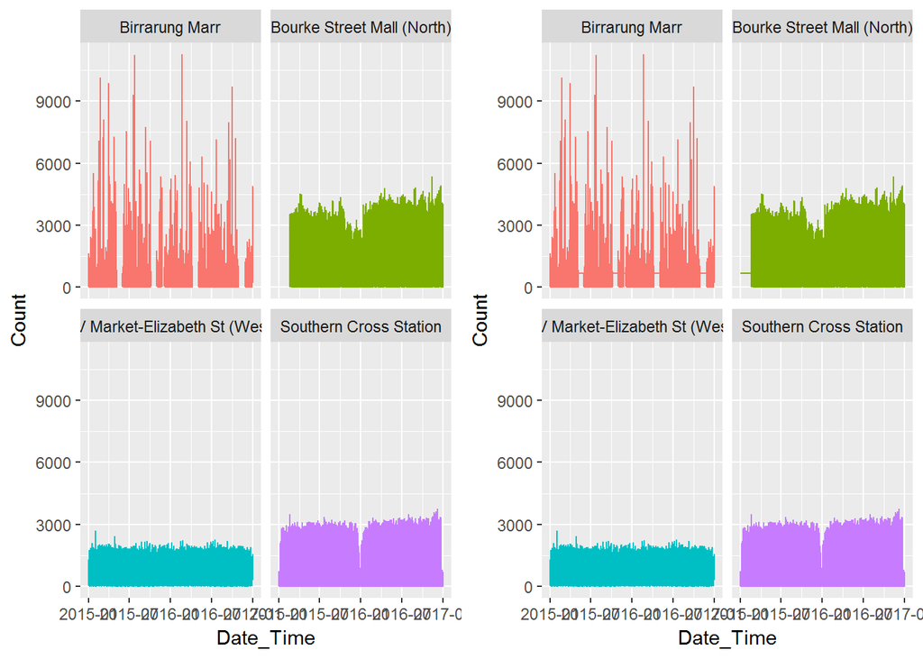

```r
na_g <- pedestrian %>%
  fill_gaps(.full=TRUE) %>%
  ggplot(aes(x=Date_Time, y=Count, color=Sensor)) +
    geom_line() +
    facet_wrap(~Sensor) +
    theme(legend.position = "none")

fill_g <- pedestrian %>%
  fill_gaps(Count = mean(Count), .full=TRUE) %>%
  ggplot(aes(x=Date_Time, y=Count, color=Sensor)) +
    geom_line() +
    facet_wrap(~Sensor) +
    theme(legend.position = "none")

cowplot::plot_grid(na_g, fill_g)
```

# 6 윈도우 함수 [^3]

시계열 데이터는 엄격한 시간 순서를 따르기 때문에 이를 기반으로 연산작업을 수행할 수 있다. 대표적인 시계열 연산이 이동평균을 들 수 있다. 명사 `tsibble` 객체에 다음 세가지 유형의 시계열 동사를 이동 윈도우에 적용시킬 수 있다.

- `slide()`/`slide2()`/`pslide()`: 겹치는 시계열 관측점을 갖는 슬라이딩 윈도우
- `tile()`/`tile2()`/`ptile()`: 겹치지 않는 시계열 관측점을 갖는 타일 윈도우
- `stretch()`/`stretch2()`/`pstretch()`: 초기 윈도우를 고정시키고 관측점을 추가

`pedestrian` 데이터는 호주 멜버른시 시간대별 보행자수를 담고 있는 시계열 데이터로 `Sensor`가 키역할을 담당하고 `Date_Time`가 시계열 인덱스를 나타내고 있다. 결측값이 포함되어 있기 때문에 `fill_gaps`로 시계열 결측을 처리한다.

```r
pedestrian_tsbl <- pedestrian %>%
  fill_gaps(.full = TRUE)
pedestrian_tsbl
```

```
# A tsibble: 70,176 x 5 [1h] <Australia/Melbourne>
# Key:       Sensor [4]
   Sensor         Date_Time           Date        Time Count
   <chr>          <dttm>              <date>     <int> <int>
 1 Birrarung Marr 2015-01-01 00:00:00 2015-01-01     0  1630
 2 Birrarung Marr 2015-01-01 01:00:00 2015-01-01     1   826
 3 Birrarung Marr 2015-01-01 02:00:00 2015-01-01     2   567
 4 Birrarung Marr 2015-01-01 03:00:00 2015-01-01     3   264
 5 Birrarung Marr 2015-01-01 04:00:00 2015-01-01     4   139
 6 Birrarung Marr 2015-01-01 05:00:00 2015-01-01     5    77
 7 Birrarung Marr 2015-01-01 06:00:00 2015-01-01     6    44
 8 Birrarung Marr 2015-01-01 07:00:00 2015-01-01     7    56
 9 Birrarung Marr 2015-01-01 08:00:00 2015-01-01     8   113
10 Birrarung Marr 2015-01-01 09:00:00 2015-01-01     9   166
# ... with 70,166 more rows
```

# 7 이동평균

`slide_dbl()` 함수를 마치 `map_dbl()`와 같이 사용해서 이동평균을 구할 수 있고, `.align=` 인자를 통해 이동평균 적용 인덱스도 지정시킬 수 있다.

```r
pedestrian_tsbl %>%
  group_by(Sensor) %>%
  mutate(Daily_MA = slide_dbl(Count, mean, na.rm = TRUE, .size = 3, .align = "center"
  ))
```

```
# A tsibble: 70,176 x 6 [1h] <Australia/Melbourne>
# Key:       Sensor [4]
# Groups:    Sensor [4]
   Sensor         Date_Time           Date        Time Count Daily_MA
   <chr>          <dttm>              <date>     <int> <int>    <dbl>
 1 Birrarung Marr 2015-01-01 00:00:00 2015-01-01     0  1630     NA
 2 Birrarung Marr 2015-01-01 01:00:00 2015-01-01     1   826   1008.
 3 Birrarung Marr 2015-01-01 02:00:00 2015-01-01     2   567    552.
 4 Birrarung Marr 2015-01-01 03:00:00 2015-01-01     3   264    323.
 5 Birrarung Marr 2015-01-01 04:00:00 2015-01-01     4   139    160
 6 Birrarung Marr 2015-01-01 05:00:00 2015-01-01     5    77     86.7
 7 Birrarung Marr 2015-01-01 06:00:00 2015-01-01     6    44     59
 8 Birrarung Marr 2015-01-01 07:00:00 2015-01-01     7    56     71
 9 Birrarung Marr 2015-01-01 08:00:00 2015-01-01     8   113    112.
10 Birrarung Marr 2015-01-01 09:00:00 2015-01-01     9   166    176.
# ... with 70,166 more rows
```

# 8 달력기간

일별/주별/월별로 연산작업을 수행하고자 하는 경우 `tsibble` 객체에 리스트칼럼 개념을 도입할 경우 탈력적으로 작업할 수 있다. 먼저 월별로 시계열 데이터를 묶는 경우를 살펴보자. `nest()` 함수를 사용해서 월별로 데이터를 묶어낸다.

```r
pedestrian_mth_tsbl <- pedestrian_tsbl %>%
  mutate(YrMth = yearmonth(Date_Time)) %>%
  nest(-Sensor, -YrMth)
pedestrian_mth_tsbl
```

```
# A tibble: 96 x 3
   Sensor           YrMth data
   <chr>            <mth> <list>
 1 Birrarung Marr  2015 1 <tsibble [744 x 4]>
 2 Birrarung Marr  2015 2 <tsibble [672 x 4]>
 3 Birrarung Marr  2015 3 <tsibble [744 x 4]>
 4 Birrarung Marr  2015 4 <tsibble [721 x 4]>
 5 Birrarung Marr  2015 5 <tsibble [744 x 4]>
 6 Birrarung Marr  2015 6 <tsibble [720 x 4]>
 7 Birrarung Marr  2015 7 <tsibble [744 x 4]>
 8 Birrarung Marr  2015 8 <tsibble [744 x 4]>
 9 Birrarung Marr  2015 9 <tsibble [720 x 4]>
10 Birrarung Marr 2015 10 <tsibble [743 x 4]>
# ... with 86 more rows
```

다음으로 앞선 `slide_dbl()` 함수에 `.size=1`로 지정하게 되면 월별 연산작업을 수행할 수 있다. 하지만, 3개월/6개월/12개월 작업을 할 경우 월별 리스트칼럼 데이터를 결합시켜야 한다. 예를 들어 분기별로 통계량을 계산하고자 할 경우 `.size=3`으로 지정하고 `.bind = TRUE`으로 설정한 후 3개월 이동평균을 계산하는 작업을 수행한다.

```r
pedestrian_mth_tsbl %>%
  group_by(Sensor) %>%
  mutate(Monthly_MA = slide_dbl(data,
    ~ mean(.$Count, na.rm = TRUE), .size = 3, .align = "center", .bind = TRUE
  ))
```

```
# A tibble: 96 x 4
# Groups:   Sensor [4]
   Sensor           YrMth data                Monthly_MA
   <chr>            <mth> <list>                   <dbl>
 1 Birrarung Marr  2015 1 <tsibble [744 x 4]>        NA
 2 Birrarung Marr  2015 2 <tsibble [672 x 4]>       634.
 3 Birrarung Marr  2015 3 <tsibble [744 x 4]>       546.
 4 Birrarung Marr  2015 4 <tsibble [721 x 4]>       554.
 5 Birrarung Marr  2015 5 <tsibble [744 x 4]>       397.
 6 Birrarung Marr  2015 6 <tsibble [720 x 4]>       429.
 7 Birrarung Marr  2015 7 <tsibble [744 x 4]>       390.
 8 Birrarung Marr  2015 8 <tsibble [744 x 4]>       398.
 9 Birrarung Marr  2015 9 <tsibble [720 x 4]>       392.
10 Birrarung Marr 2015 10 <tsibble [743 x 4]>       539.
# ... with 86 more rows
```

# 9 달력기간별 회귀분석

`filter_index()` 함수로 “2015-03”월까지 추출하고 센서(`Sensor`)별로 묶은 후에 앞서 정의한 `fit_reg()` 함수를 적용시켜 회귀분석을 수행한다.

```r
fit_reg <- function(...) {
  data <- tibble(...)
  fit <- lm(Count ~ Time, data = data)
  list(fitted = fitted(fit), resid = residuals(fit))
}

pedestrian_reg_tsbl <- pedestrian %>%
  filter_index(~ "2015-03") %>%
  nest(-Sensor) %>%
  mutate(reg = purrr::map(data, ~ pslide_dfr(., fit_reg, .size = 24 * 7)))

pedestrian_reg_tsbl
```

```
# A tibble: 4 x 3
  Sensor                        data                  reg
  <chr>                         <list>                <list>
1 Birrarung Marr                <tsibble [2,160 x 4]> <tibble [334,825 x 2~
2 Bourke Street Mall (North)    <tsibble [1,032 x 4]> <tibble [145,321 x 2~
3 QV Market-Elizabeth St (West) <tsibble [2,160 x 4]> <tibble [334,825 x 2~
4 Southern Cross Station        <tsibble [2,160 x 4]> <tibble [334,825 x 2~
```

```r
pedestrian_reg_tsbl$reg[[1]]
```

```
# A tibble: 334,825 x 2
   fitted   resid
    <dbl>   <dbl>
 1    NA     NA
 2   161.  1469.
 3   170.   656.
 4   179.   388.
 5   189.    75.3
 6   198.   -59.1
 7   208.  -131.
 8   217.  -173.
 9   226.  -170.
10   236.  -123.
# ... with 334,815 more rows
```

[^1]: [Earo Wang, “Introduction to tsibble - Vignette”](https://cran.r-project.org/web/packages/tsibble/vignettes/intro-tsibble.html)
[^2]: [Earo Wang, “Handle implicit missingness with tsibble”](https://cran.rstudio.com/web/packages/tsibble/vignettes/implicit-na.html)
[^3]: [Earo Wang “A family of window functions”“](https://cran.rstudio.com/web/packages/tsibble/vignettes/window.html)